# Model Termal Dinamis Empat Regime dan Tiga *Solver*

Progress Update — Langkah 5 (eksplorasi model transien) · Risk-Constrained Probabilistic Thermal Rating, J-Tube Kabel Ekspor Offshore Wind

Joko Pawitro — NRP 6022251005

Program Magister, Rekayasa Elektrik Berkelanjutan — Departemen Teknik Elektro, ITS

2026-10-05

## Agenda

**1. Progress minggu ini (28 Sep – 4 Okt)**

- Empat regime batas termal: kabel terkubur, J-tube di udara, J-tube terendam, *free span*: masing-masing dengan jaringan RC dan validasinya.
- Tiga *solver* dinamis lintas empat regime: kuasi-stasioner (IEC 60287 per jam), IEC 60853-2 (transien standar), RC *lumped* (Diaz-Aguiló), diuji terhadap model *finite-volume* independen.
- Langkah 5b-ii selesai: metode rugi TB 908 Method 1 dapat dipilih di iterasi rating kabel terkubur (kuasi-stasioner dan RC *lumped*).
- Status: eksplorasi transien ditutup (HD7 opsi b, studi samping); *pipeline* `I_α` tetap kuasi-stasioner.

**2. Rencana minggu depan (5 – 11 Okt)**

- *Solver* transien per-lapisan kabel (TB 880): rencana dan strategi validasi.
- Langkah 4: skenario *block-bootstrap* Monte Carlo (sesuai jadwal Okt–Nov).
- Langkah 6: kerangka penetapan `I_α` dan keputusan yang masih mengunci.

## 1. Progress minggu ini — status dan jadwal

**Langkah 1–5**

| Langkah | Status |
| --- | --- |
| 1 | ✅ |
| 2 | ✅ |
| 3 | ✅ |
| 4 | ❌ |
| 5 | ✅ |
| 5a | ✅ |
| 5b-i | ✅ |
| 5b-ii | ✅ |
| 5c | ✅ |
| 5d | ✅ |
| 5e | ✅ |
| 5f | ✅ |
| Program *solver* transien | ✅ (ditutup, HD7 opsi b) |

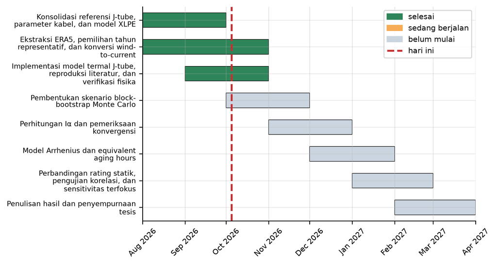

**Caption:** Langkah 5 selesai (5b-ii: metode rugi TB 908 pada rating regime terkubur; penerapan ke kabel tesis menyusul); Langkah 4 mulai minggu depan sesuai slot Okt–Nov; eksplorasi transien empat regime adalah studi samping (HD7 opsi b), tidak mengubah jadwal inti. *Pipeline* `I_α` tetap kuasi-stasioner.

## 1. Progress minggu ini

Empat regime · tiga *solver* dinamis

Kabel benchmark Chippendale (2017) di keempat regime; regime terkubur memakai dasar laut TB 880 Case 8 (kombinasi hipotetis).

## 1.1 Regime 4 — kabel terkubur (TB 880, TB 908, *ladder* Diaz-Aguiló)

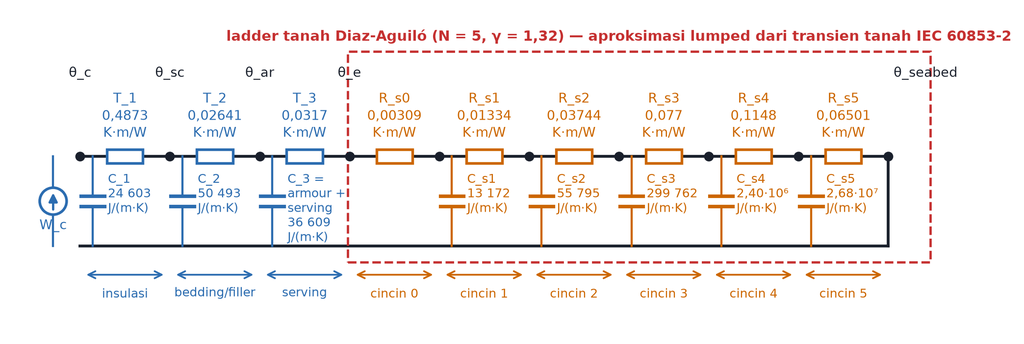

**Diagram:** C_3 = armour + serving, dikelompokkan empat-simpul. Kabel dan tanah Case 8 TB 880; hasil regime 4 memakai kabel Chippendale di tanah Case 8 (hipotetis). T_1..T_3: rantai IEC 60287 per inti.

**Catatan:**

- Lapisan internal: rantai IEC 60287 terverifikasi terhadap TB 880 Case 8 dan Case 2 (semua nilai antara, rel ≤ 1e-9).
- TB 908 Method 1 (rugi armour kabel tiga-inti) kini dapat dipilih di iterasi rating (5b-ii; regime terkubur saja): R_AC, λ₁, λ₂ sesuai TB 908 Tabel 7.4–7.8; rating ketiga kasus Method 1 −1,6 hingga −1,8 % dari nilai tercetak (sisi termal tak dicetak); rating IEC *default* 896 A meleset (−4,2 %), terbuka.
- Transien standar: IEC 60853-2 Eq. 4-36 / 4-71; Tabel F2 dan F3 Appendix F direproduksi (θ_e ≤ 0,06 K, θ ≤ 0,07 K).
- *Ladder*: total resistansi = `T_4` IEC 60287 (eksak menurut konstruksi); dalam 0,42 K dari solusi silinder eksak sampai 168 jam; di luar 168 jam diberi peringatan validitas.

- Kabel Chippendale di dasar laut Case 8 = kombinasi **hipotetis**, agar satu kabel tampil di keempat regime (rating terkubur 974,3 A vs 812,8 A udara → J-tube tetap *bottleneck*).

**Rujukan:** TB 880 (2022) CS 8; TB 908 (2023) Method 1; IEC 60287-2-1:2023; IEC 60853-2 (1989) + Amd. 1 (2008) Eq. 4-36, 4-71, App. F; Diaz-Aguiló et al. (2014); Diaz-Aguiló & de León (2015).

## 1.2 Regime 1 — J-tube di udara (Chippendale 2017)

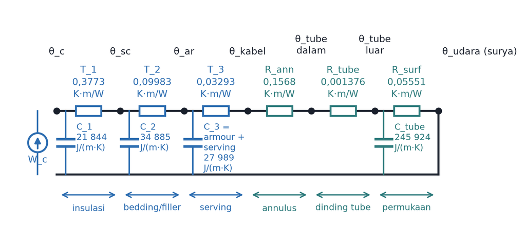

**Diagram:** T_1..T_3: rantai IEC 60287 per inti.

**Catatan:**

- Validasi *steady*: rating 812,8 A, +3,0 % vs 2D analitis (789 A), −1,8 % vs FE (828 A), di dalam selisih 2D-vs-FE miliknya sendiri (−4,7 %).

- Annulus udara tersegel (HD6): Nusselt Keyhani (1985); luas radiasi annulus = luas jaket kabel (Hartlein & Black 1983, Appendix I, neraca permukaan +0,6 %).
- Permukaan luar: Hartlein & Black (1983) Tabel I; surya terserap sebagai sumber `Q₄`.
- Transien: jaringan kabel IEC 60853-2 4.2 + simpul annulus, dinding tube, permukaan luar (tak-linear: konveksi, radiasi), *sub-stepping*; τ ≈ 4–11 jam (*dominant pole*), lebih lambat dari langkah ERA5 1 jam.
- Batas: udara diam (pemetaan angin→`h_ext` belum diputuskan), 2D, kabel benchmark (bukan kasus tesis, HD3).

**Rujukan:** IEC 60287-1-1:2023; IEC 60287-2-1:2023; Chippendale (2017); Hartlein & Black (1983); Keyhani et al. (1985).

## 1.3 Regime 2 — J-tube terendam

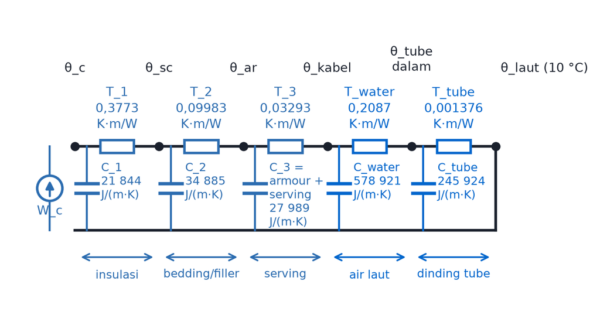

**Diagram:** T_1..T_3: rantai IEC 60287 per inti.

**Catatan:**

- Mengikuti Chippendale (2017) §VI.E: annulus berisi air laut diperlakukan sebagai lapisan konduksi padat (Eq. 28, k = 0,58 W/m·K; konveksi alami diabaikan).
- Batas luar *default* = dinding luar tube pada suhu laut 10 °C (model Chippendale); cabang *film*: Churchill–Bernstein (arus silang 0,5 m/s) + Churchill–Chu, sifat air laut Sharqawy et al. (2010) — asumsi 0,5 m/s dan 10 °C diterima 2026-10-01.
- Tanpa surya di bawah permukaan air; tanpa aliran panas longitudinal ke seksi udara/dasar laut.
- Orientasi: tube hampir vertikal, bentuk konveksi alami silinder horizontal dipakai (efek ≤ 0,1 % pada 0,5 m/s).

**Rujukan:** IEC 60287-1-1:2023; IEC 60287-2-1:2023; Chippendale (2017); Sharqawy et al. (2010); Churchill–Bernstein (1977); Churchill–Chu (1975).

## 1.4 Regime 3 — *free span*

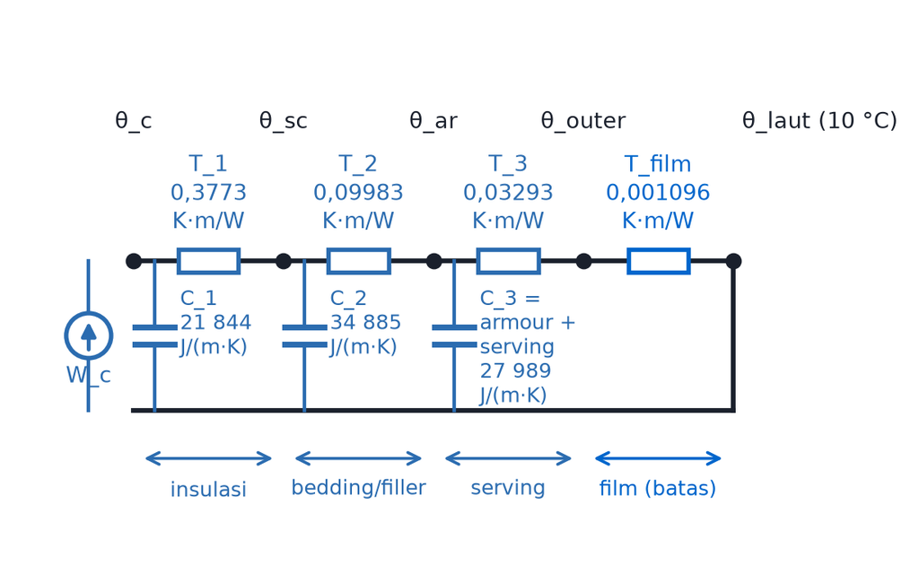

**Diagram:** T_1..T_3: rantai IEC 60287 per inti. T_4 = 0 untuk fixed_surface; T_film = cabang film (batas).

**Catatan:**

- Kabel telanjang dikelilingi air laut, tanpa tube dan tanpa kontak dasar laut.
- Tidak ada kasus Chippendale untuk kabel telanjang di air: *default* `fixed_surface` (permukaan serving = suhu laut) adalah **batas optimistis** (koefisien film tak-hingga, rating tertinggi), bukan pilihan konservatif; cabang *film* memberi batasnya.
- Film: silinder horizontal (sesuai), arus tegak lurus kabel (optimistis untuk *heading* sembarang).
- Transien `fixed_surface` identik dengan jaringan kabel IEC 60853-2 4.2 saja.

**Rujukan:** IEC 60287-1-1:2023; IEC 60287-2-1:2023; Churchill–Bernstein (1977); Churchill–Chu (1975).

## 1.5 *Solver* kuasi-stasioner — hasil

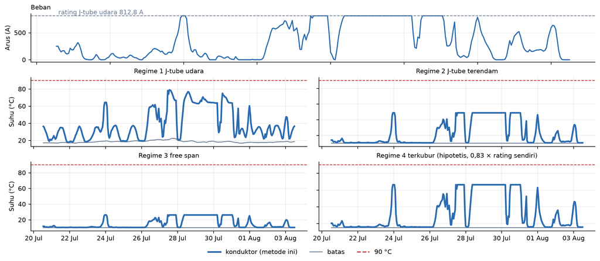

Suhu konduktor. Kabel Chippendale (2017); beban 2018 dinormalisasi ke rating J-tube udara 812,8 A (*bottleneck*).

## 1.5 *Solver* kuasi-stasioner — kualitas dan catatan

[output not shown]

Statistik tahunan 2018 setelah 30 hari *spin-up*.

- Rantai IEC 60287 per jam dengan `R_ac` bergantung suhu (*self-consistent*); *forward solver* `T_c(I)` *round-trip* ke 1e-6 K terhadap *inverse*.

- Validasi: TB 880 Case 8/2 (rel ≤ 1e-9), Chippendale (+3,0 % / −1,8 %), uji arah fisika di CI.

- Tidak menyimpan panas: pada beban naik membaca **di atas** model transien (asumsi monotonisitas RC, dasar konservatisme metode inti); karena τ ≈ 4–11 jam > 1 jam, selisihnya bukan koreksi kecil.

- Ini *default* *pipeline* `I_α` (HD8 terbuka); lookup 5f ≈ 0,003 jam untuk seluruh beban Monte Carlo.

- **Mengapa kuasi-stasioner jauh di atas transien di regime 1:** maksimum 78,9 °C terjadi 2 jam setelah beban naik dari 519 A ke 813 A (2018-07-27 11:00 UTC); pada jam itu IEC 60853-2 baru 51,8 °C. Setelah ≥ 48 jam terus-menerus pada beban rating, selisih rata-rata hanya 0,22 K (583 jam): selisih besar berasal dari jeda termal (τ ≈ 4–11 jam), bukan dari kondisi tunak.

**Rujukan:** IEC 60287-1-1:2023, IEC 60287-2-1:2023, Chippendale (2017), TB 880.

## 1.6 IEC 60853-2 — hasil

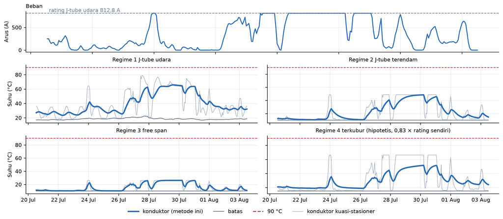

Suhu konduktor. Kabel Chippendale (2017); beban 2018 dinormalisasi ke rating J-tube udara 812,8 A (*bottleneck*).

## 1.6 IEC 60853-2 — kualitas dan catatan

[output not shown]

Statistik tahunan 2018 setelah 30 hari *spin-up*.

- Appendix F direproduksi: Tabel F3 θ_c ≤ 0,1 K, α ≤ 0,002; Tabel F2 θ_e ≤ 0,06 K.
- Jaringan dua-seksi 4.2 dipakai di bawah rentang Klausul 4.1.4 untuk kabel tiga-inti ini (½ T·Q = 3,0 jam); terhadap metode `auto` (4.3/interpolasi) selisihnya ≤ 0,6 K pada jam 1–2.
- Di udara/air: `T_B → T_B + q_a T_4` tanpa kapasitansi eksternal (4.2.4.2, 4.4.1.2); pembaruan eksternal per jam adalah **perluasan** aturan `T_4` konstan yang tercetak.
- IEC 60853-2 sesuai dengan arbiter *finite-volume* dalam 0,02 K setelah satu bulan.
- Pada profil 2018 (Case 8, 1,0 ×, `theta_max`) maksimum tahunan sesuai dalam 0,05 K (IEC) dan 0,4 K (*ladder* dan fisik, keduanya di atas); galat per jam mencapai 1,5–3,8 K.
- Dalam hari pertama IEC bukan batas: hingga 1,5 K lebih rendah pada 1 jam; campuran pada 3 jam (Case 8 +0,7 K, kabel Chippendale −0,8 K); hingga 2,5 K lebih tinggi pada 6–24 jam.

Beban lebih: kabel hipotetis terkubur pada 1,25 × rating J-tube = **4 % di atas rating terkubur sendiri** — kuasi-stasioner 97,0 °C dan 3901 jam > 90 °C vs transien IEC 91,5 °C dan 69 jam (*lagged*).

**Rujukan:** IEC 60853-2 (1989) + Amd. 1 (2008), Cl. 4.1.4, 4.2, 4.4.1.2, App. F; Anders (1997).

## 1.7 RC *lumped* (Diaz-Aguiló) — hasil

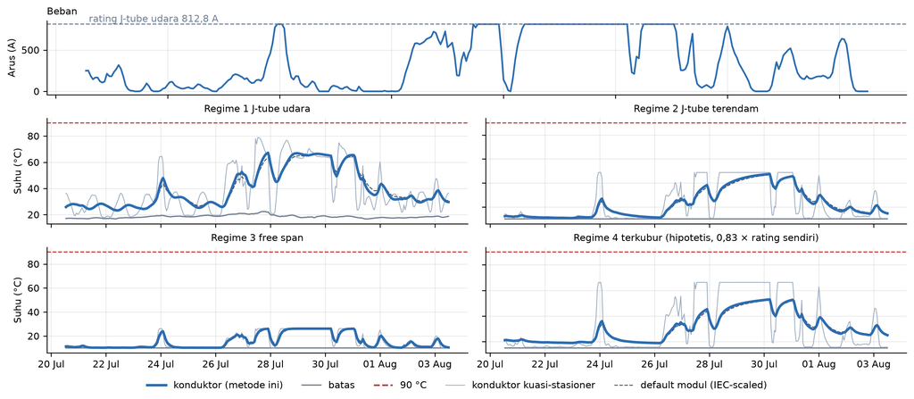

Suhu konduktor. Kabel Chippendale (2017); beban 2018 dinormalisasi ke rating J-tube udara 812,8 A (*bottleneck*).

## 1.7 RC *lumped* — kualitas dan catatan

[output not shown]

Statistik tahunan 2018 setelah 30 hari *spin-up*.

- Arbiter: model *finite-volume* 2D satu kabel terkubur (kabel konsentris ekuivalen, data lapisan sama dengan model *lumped*). Galat numerik < 0,02 K; ketidakpastian konstruksi hingga sekitar 0,6 K dalam 6 jam pertama (sebaran konduktor 0,64 K; posisi cincin *sheath* 0,3 K, 0,75 K pada 3–24 jam sebagai batas), < 0,01 K setelah satu minggu.
- *Ladder* Diaz-Aguiló terbaca hingga 3,8 K lebih rendah dari arbiter pada 3–12 jam untuk kabel Chippendale rugi-tinggi (q_a sekitar 2), hampir seluruhnya dari penskalaan q rugi *sheath* dan armour (+0,35 K bila rugi itu dimatikan); 1,6 K lebih rendah untuk Case 8.
- Kabel empat-simpul satuan fisik berada dalam 0,45 K dari arbiter dari 3 jam sampai satu minggu (−1,1 K pada 1 jam).
- Catatan: kabel konsentris ekuivalen (geometri tiga-inti tidak diuji; radius konstruksi divariasikan seperti di atas); satu kabel, tanah homogen, tanpa rugi dielektrik pada uji *step*; kasus rugi-tinggi adalah kabel Chippendale di dasar laut Case 8 (hipotetis), bukan kabel tesis.
- Mesin RC: IEC 60853-2 4.2 / Anders (1997); Diaz-Aguiló (2014) hanya untuk diskretisasi tanah (N = 5, γ = 1,32), (2015) untuk *mutual heating*. Tidak ada kode internal perusahaan yang dipakai (*clean-room*).
- **Ladder vs implementasi IEC:** meleset dari target 0,5 K (3,5 K Case 8, 4,7 K Chippendale pada step) — dinyatakan sebagai batas.
- Dibandingkan *lumping* satuan fisik, jaringan berskala IEC membaca kenaikan awal suhu konduktor sekitar 2–7 K terlalu rendah pada 3–24 jam untuk kabel rugi-tinggi ini. Tanda ini berlaku untuk setiap pemisahan yang diuji; besarnya bergantung pada asumsi *lumping* yang belum divalidasi. Kondisi tunak identik, sehingga `I_α` kuasi-stasioner tidak terpengaruh.
- Pada 1,25 × rating regime 1 untuk profil 2018, maksimum tahunan 1,9 K (`theta_max`) / 2,3 K (`lagged`) lebih tinggi dengan kabel fisik. Jam di atas 90 °C: 5 vs 18 dan 1 vs 16. Hitungan ini sensitif terhadap ambang (puncak berskala hanya 0,38 / 0,03 K di atas 90 °C).
- Kesesuaian 0,45 K berada **di dalam** ketidakpastian konstruksi arbiter sendiri: menunjukkan konsistensi dalam idealisasi konsentris, bukan peringkat yang terselesaikan.
- **Isu terbuka:** konvensi panas internal kabel bila rugi *sheath*/armour besar — rugi ditempatkan di konduktor dengan kapasitansi diskalakan (IEC 4.2.2.2) atau panas di simpulnya sendiri. *Solver* per-lapisan (slide 16) akan menjawabnya secara langsung.

**Rujukan:** IEC 60853-2; Anders (1997); Diaz-Aguiló et al. (2014); Diaz-Aguiló & de León (2015).

## 2. Rencana minggu depan

*Solver* per-lapisan · Langkah 4 · Langkah 6

## 2.1 *Solver* transien per-lapisan kabel — rencana dan validasi

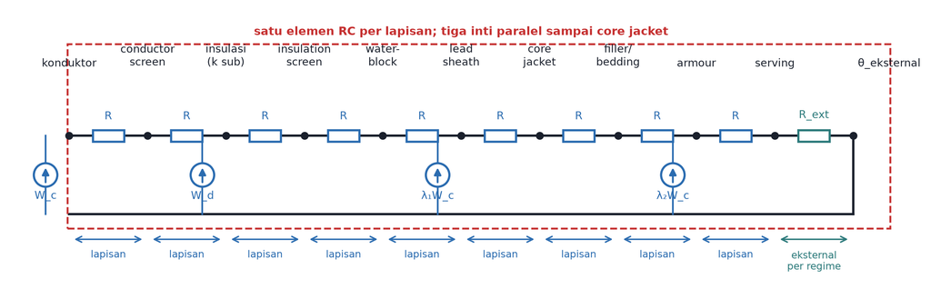

**Mengapa:** Kabel sudah dibangun per lapisan dari TB 880 dan rantai *steady* memakai setiap lapisan, tetapi jaringan IEC 60853-2 4.2 meringkasnya menjadi dua simpul (faktor van Wormer), dan model fisik menjadi empat. *Solver* per-lapisan akan memberi suhu setiap lapisan secara transien (konduktor, *sheath*, armour, *cover*), menjawab pertanyaan konvensi panas internal, dan menjadi dasar bila kelak data serat optik (DTS) tersedia.

**Rencana validasi (direncanakan):**

1. **Limit *steady*:** suhu setiap lapisan = rantai IEC 60287 (TB 880 Case 8; Case 2 termasuk θ_sc, θ_ar terpublikasi) pada rel ≤ 1e-9.
2. **Reduksi ke standar:** bila lapisan digabung menurut aturan 4.2 (van Wormer), *ladder* mereproduksi Appendix F Tabel F3 (θ_c ≤ 0,1 K), sehingga model standar adalah kasus khusus.
3. **Konvergensi diskretisasi:** jumlah sub-cincin insulasi dan filler ditambah sampai respons konduktor berubah < 0,02 K.
4. **Arbiter *finite-volume*:** dibandingkan dengan model FV kabel terkubur pada suhu konduktor **dan** rata-rata wilayah *sheath*/armour; target: dalam ketidakpastian konstruksi arbiter (≈ 0,6 K pada 1–6 jam), ≤ 0,02 K setelah satu minggu.
5. **Konsistensi:** neraca energi, uji arah fisika di CI, dan selisih terhadap model empat-simpul dilaporkan per lapisan.

**Scope:** Metode tambahan yang bisa dipilih di *solver registry*, bukan *default*; tidak mengubah *pipeline* `I_α` (HD7 opsi b). Prioritas di bawah Langkah 4 (jalur kritis).

**Rujukan:** Anders (1997); IEC 60853-2 (1989) + Amd. 1 (2008) Cl. 4.2; CIGRE TB 880 (2022) CS 8, CS 2.

## 2.2 Langkah 4 — skenario *block-bootstrap* Monte Carlo

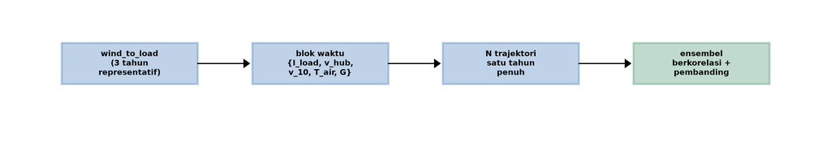

- Masukan: keluaran Langkah 3 untuk 2017 / 2018 / 2021 (angin tinggi / median / rendah); tidak bergantung pada model termal.
- Blok waktu diambil **berbaris** (semua variabel dari jam yang sama), sehingga korelasi beban–pendinginan terjaga.
- Panjang blok: dipilih ≥ beberapa τ (τ ≈ 4–11 jam), kandidat 24–168 jam; diuji terhadap autokorelasi dan lonjakan pada sambungan blok.
- Keluaran: trajektori **kontinu satu tahun penuh** per (tahun, k), bukan potongan 24 jam, agar *solver* transien tetap bisa dipakai kelak (sensitivitas Langkah 8).
- Pembanding independensi (wajib): blok di-desinkronisasi (jendela kalender sama, tahun lain, atau geseran sirkular dalam musim), **bukan** pengacakan per jam; laporkan korelasi lag-0 `I_load`–`v_10` untuk kedua ensembel.
- Konvergensi: N awal 1000; `I_α` dan kuantil P95/P99 `T_c` stabil terhadap penambahan N.
- Target minggu depan: modul `scenarios/`, uji, dan *notebook* dokumentasi.

**Rujukan:** Künsch (1989); Hersbach et al. (2020).

## 2.3 Langkah 6 — penetapan `I_α`

$$\hat P_\text{exc}(m) = \frac{1}{N} \sum_k \mathbf{1}\left[\max_{t \in H} T_c^{(k)}(t;m) > T_{\max}\right] \le \alpha$$

dengan $I_\alpha = m_\alpha I_\text{ref}$, $\alpha \in \{0{,}10;\ 0{,}05;\ 0{,}01\}$ dan *rolling* 24 jam *horizon*.

- Grid multiplier `m` di atas tabel precompute 5f (kuasi-stasioner): seluruh beban N × grid × 3 tahun ≈ 0,003 jam.
- Yang masih mengunci (keputusan, bukan kode): pemetaan angin ERA5 → `h_ext` permukaan luar tube (precompute masih udara diam, konservatif); HD3 kabel & armour kasus tesis; HD2 jumlah sirkuit (beban ERA5 ≈ 3,4 × rating kabel benchmark); HD4 arti `T_max`.
- Minggu depan: kerangka *grid search* dan uji pada skenario Langkah 4 pertama; usulan pemetaan angin→`h_ext` untuk diputuskan.
- *Solver* transien di *pipeline* menyusul setelah Langkah 6 sebagai sensitivitas Langkah 8 (HD8), bukan *default*.

**Rujukan:** metode proposal; Høyer-Hansen et al. (2022).

## Dokumen rujukan

| Dokumen | Dipakai untuk |
| --- | --- |
| IEC 60287-1-1:2023 | kuasi-stasioner, J-tube, *free span* |
| IEC 60287-2-1:2023 | kabel terkubur, rantai internal |
| IEC 60853-2 (1989) + Amd. 1 (2008) | semua regime transien, Appendix F |
| CIGRE TB 880 (2022) | data kabel terkubur Case 8 dan Case 2 |
| CIGRE TB 908 (2023) | metode rugi armour |
| Chippendale et al. (2017) | kabel benchmark J-tube |
| Høyer-Hansen et al. (2022) | film eksternal, alternatif `h_ext` |
| Hartlein & Black (1983) | radiasi annulus J-tube |
| Keyhani et al. (1985) | Nusselt annulus J-tube |
| Churchill & Bernstein (1977) | koefisien film (arus silang) |
| Churchill & Chu (1975) | konveksi alami (silinder horizontal) |
| Sharqawy et al. (2010) | sifat air laut |
| Diaz-Aguiló et al. (2014) | geometri dan diskretisasi *ladder* tanah |
| Diaz-Aguiló & de León (2015) | pemanasan timbal-balik *ladder* tanah |
| Anders (1997) | mesin jaringan RC |
| Hersbach et al. (2020) | data cuaca ERA5 |
| Künsch (1989) | metode *block bootstrap* |